# Vet Sim course; Week 2 Day 1

Carsten Kirkeby

Exercises with herd dynamics

# 1. Introducing herd dynamics

We start by constructing a simple simulation model for a dairy farm, and use an age counter (days) to the cows.

Please look at the code and make sure you understand what each line does.

First we construct a herd with cows that age over time:

```r
set.seed(250)

n.cows <- 100

# Create the farm:
farm <- data.frame(id =1:n.cows,
                   age=round(runif(n.cows,730,1642)))

# Create the farm:
farm <- data.frame(id =1:n.cows,
                   age=round(runif(n.cows,730,1642)))

# We want to simulate 5 years:
end.time <- 5 * 365

# Collect the mean age of the cows in herd over time:
age_collect <- numeric(end.time)

for (k in 1:end.time)
{

   # Add one day to the age of all the animals, for each simulated:
   farm$age <- farm$age + 1

   # Save the daily mean age of all cows:
   age_collect[k] <- mean(farm$age)
}
```

We can then plot the age of the cows over time:

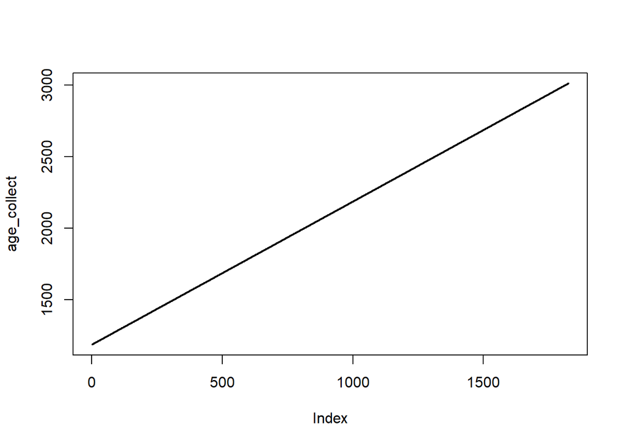

```r
plot(age_collect, type="l", lwd=2)
```

We see that the cows age over time as the mean age in the herd increases. However, this does not reflect a real herd. We want to model a cattle farm where the old cows are replaced with new cows over time. When the cows reach 1642 days, they will be replaced with a new cow that is two years old:

```r
set.seed(250)

n.cows <- 100

# Create the farm:
farm <- data.frame(id =1:n.cows,
                   age=round(runif(n.cows,730,1642)))

# Create the farm:
farm <- data.frame(id =1:n.cows,
                   age=round(runif(n.cows,730,1642)))

# Collect the mean age of the cows in herd over time:
age_collect <- numeric(end.time)

# We want to simulate 5 years:
end.time <- 5 * 365

for (k in 1:end.time)
{
   # If cows reach the age of 1642, they are replaced with a new cow that is 2 years old in DIM = 1:
   farm$age[farm$age==1642] <- 730

   # Add one day to the age of all the animals, for each simulated:
   farm$age <- farm$age + 1

   # Save the daily mean age of all cows:
   age_collect[k] <- mean(farm$age)
}
```

We can then plot the age of the cows over time:

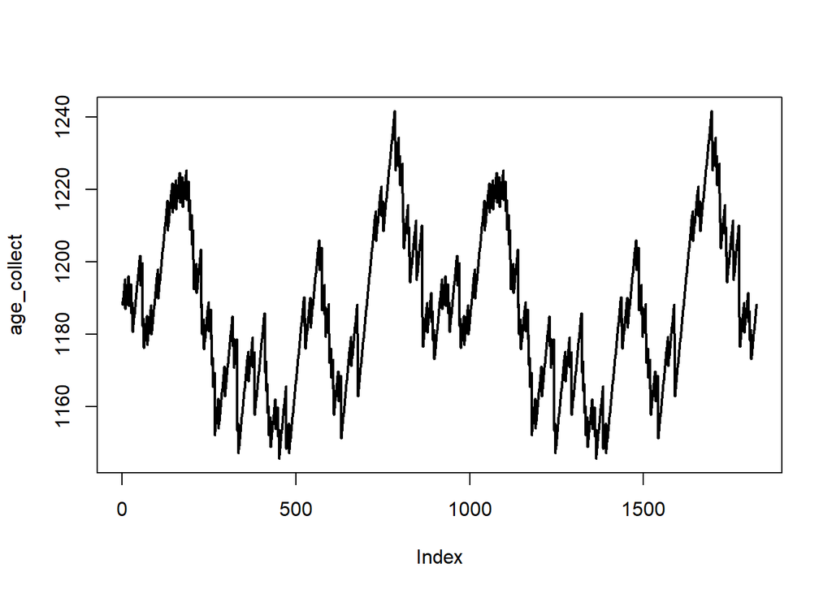

```r
plot(age_collect, type="l", lwd=2)
```

The mean age in the herd oscillates over time, as a natural cause of the dynamics in the herd when cows age and are replaced with new cows.

We can look at the variation in the age over time:

```r
quantile(age_collect)
```

```
##      0%     25%     50%     75%    100%
## 1145.69 1170.33 1184.37 1201.93 1241.57
```

# 2. Exercises

Hint: Modify the above code to solve the exercises.

## A.

What happens with the variation if you increase the number of cows to 200? And 500?

## B.

Try to change the age before replacement up and down. What happens with the variation in the results?

## C.

Now introduce dynamics in the replacement age: Make a new column with an individual replacement age for each cow (normal distribution with mean = 1642 and sd=50). When the cows reach their own predefined replacement age, then replace them. Remember that the new cows should have their own replacement age. What happens?

## D.

What modification would you like to introduce to this model, to explore the dynamics in the herd?